# BRMS Workshop: Basics of Bayesian Regression

BRMS Workshop

2025-12-16

# Introduction to BRMS

Welcome to the Bayesian Regression Models using Stan (BRMS) workshop!

## [!] First Time Setup Notes

- **If prompted to install packages**: Your environment may need CmdStan. Reply **“y”** to install.
- **First model runtime**: ~30-60 seconds (compilation happens once)
- **Subsequent models**: <5 seconds (very fast!)
- **In container**: Everything pre-installed, should run without prompts
- **In Binder**: May prompt for first-time CmdStan setup (normal)

## Environment Check

If you encounter any installation prompts, run this chunk to diagnose:

```r
# Uncomment and run if you see installation prompts

cat("=== Environment Diagnostics ===\n\n")

cat("R Version:\n")
print(R.version$version.string)

cat("\nCmdStan Installation Status:\n")
if (requireNamespace("cmdstanr", quietly = TRUE)) {
  cmdstanr_path <- try(cmdstanr::cmdstan_path(), silent = TRUE)
  if (inherits(cmdstanr_path, "try-error")) {
    cat("- cmdstanr installed but CmdStan not found\n")
    cat("- Run: cmdstanr::install_cmdstan()\n")
  } else {
    cat("✓ CmdStan found at:", cmdstanr_path, "\n")
  }
} else {
  cat("- cmdstanr not installed\n")
  cat("- Run: install.packages('cmdstanr')\n")
}

cat("\nBRMS Configuration:\n")
cat("- Backend:", getOption("brms.backend", "default"), "\n")
cat("- Cores:", getOption("mc.cores", "default"), "\n")
```

# Part 1: Data Preparation

First, let’s load required packages and prepare our data.

```r
cat("Loading required packages...\n")
```

```r
# Load packages with better error handling
tryCatch({
  library(rstan)       # Load rstan first for compatibility
  library(brms)        # Bayesian Regression Models using Stan
  library(tidyverse)   # Data manipulation
  library(bayesplot)   # Posterior visualization
  library(ggplot2)     # Plotting
  cat("✓ All packages loaded successfully\n")
  cat("✓ BRMS backend:", getOption("brms.backend", "rstan"), "\n")
}, error = function(e) {
  cat("Error loading packages:\n")
  print(e)
  cat("\nIf prompted to install missing packages, reply 'y' to install.\n")
})
```

```
##
## rstan version 2.32.7 (Stan version 2.32.2)
```

[output not shown]

```
## Loading 'brms' package (version 2.23.0). Useful instructions
## can be found by typing help('brms'). A more detailed introduction
## to the package is available through vignette('brms_overview').
```

[output not shown]

```
## ✓ All packages loaded successfully
## ✓ BRMS backend: cmdstanr
```

Let’s create a simple dataset to work with:

```r
# Simulated data: effect of study time on exam scores
set.seed(42)
n <- 100

data_study <- tibble(
  student_id = 1:n,
  study_hours = rnorm(n, mean = 5, sd = 2),
  score = 40 + 8 * study_hours + rnorm(n, 0, 10)
) %>%
  mutate(
    study_hours = pmax(study_hours, 0),  # Can't have negative study hours
    score = pmin(pmax(score, 0), 100)     # Scores between 0-100
  )

# Explore the data
head(data_study, 10)
```

```
## # A tibble: 10 × 3
##    student_id study_hours score
##         <int>       <dbl> <dbl>
##  1          1        7.74 100
##  2          2        3.87  81.4
##  3          3        5.73  75.8
##  4          4        6.27 100
##  5          5        5.81  79.8
##  6          6        4.79  79.4
##  7          7        8.02 100.
##  8          8        4.81  77.3
##  9          9        9.04 100
## 10         10        4.87  80.2
```

```r
summary(data_study)
```

```
##    student_id      study_hours        score
##  Min.   :  1.00   Min.   :0.000   Min.   : 26.78
##  1st Qu.: 25.75   1st Qu.:3.767   1st Qu.: 70.18
##  Median : 50.50   Median :5.180   Median : 79.94
##  Mean   : 50.50   Mean   :5.078   Mean   : 78.50
##  3rd Qu.: 75.25   3rd Qu.:6.323   3rd Qu.: 92.04
##  Max.   :100.00   Max.   :9.573   Max.   :100.00
```

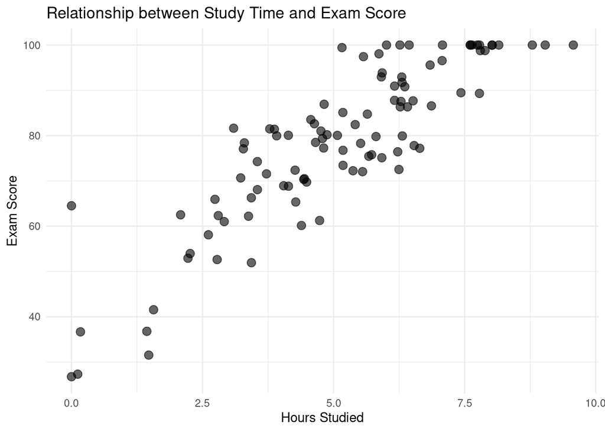

```r
ggplot(data_study, aes(x = study_hours, y = score)) +
  geom_point(size = 3, alpha = 0.6) +
  theme_minimal() +
  labs(
    title = "Relationship between Study Time and Exam Score",
    x = "Hours Studied",
    y = "Exam Score"
  )
```

# Part 2: Simple Linear Regression

Let’s fit a Bayesian linear regression model. This is our first BRMS model!

**Note**: The first model takes ~30-60 seconds to compile, then subsequent models are fast.

```r
cat("Fitting Bayesian linear regression...\n")
```

```
## Fitting Bayesian linear regression...
```

```r
model1 <- brm(
  formula = score ~ study_hours,
  data = data_study,
  family = gaussian(),
  chains = 2,      # 2 parallel chains for speed (normal: 4)
  iter = 2000,     # Total iterations per chain
  warmup = 1000,   # Burn-in iterations
  cores = 2,       # Parallel processing
  refresh = 0      # Suppress iteration printing
)
```

```
## Running MCMC with 2 parallel chains...
##
## Chain 1 finished in 0.0 seconds.
## Chain 2 finished in 0.0 seconds.
##
## Both chains finished successfully.
## Mean chain execution time: 0.0 seconds.
## Total execution time: 0.3 seconds.
```

```r
cat("Model fitting complete!\n")
```

```
## Model fitting complete!
```

Let’s examine the model:

```r
# Summary of posterior distributions
summary(model1)
```

```
##  Family: gaussian
##   Links: mu = identity
## Formula: score ~ study_hours
##    Data: data_study (Number of observations: 100)
##   Draws: 2 chains, each with iter = 2000; warmup = 1000; thin = 1;
##          total post-warmup draws = 2000
##
## Regression Coefficients:
##             Estimate Est.Error l-95% CI u-95% CI Rhat Bulk_ESS Tail_ESS
## Intercept      40.88      2.28    36.42    45.12 1.00     1839     1387
## study_hours     7.42      0.42     6.61     8.25 1.00     1880     1504
##
## Further Distributional Parameters:
##       Estimate Est.Error l-95% CI u-95% CI Rhat Bulk_ESS Tail_ESS
## sigma     8.76      0.62     7.68    10.10 1.00     1831     1142
##
## Draws were sampled using sample(hmc). For each parameter, Bulk_ESS
## and Tail_ESS are effective sample size measures, and Rhat is the potential
## scale reduction factor on split chains (at convergence, Rhat = 1).
```

# Part 3: Posterior Visualization

Visualize the posterior distributions:

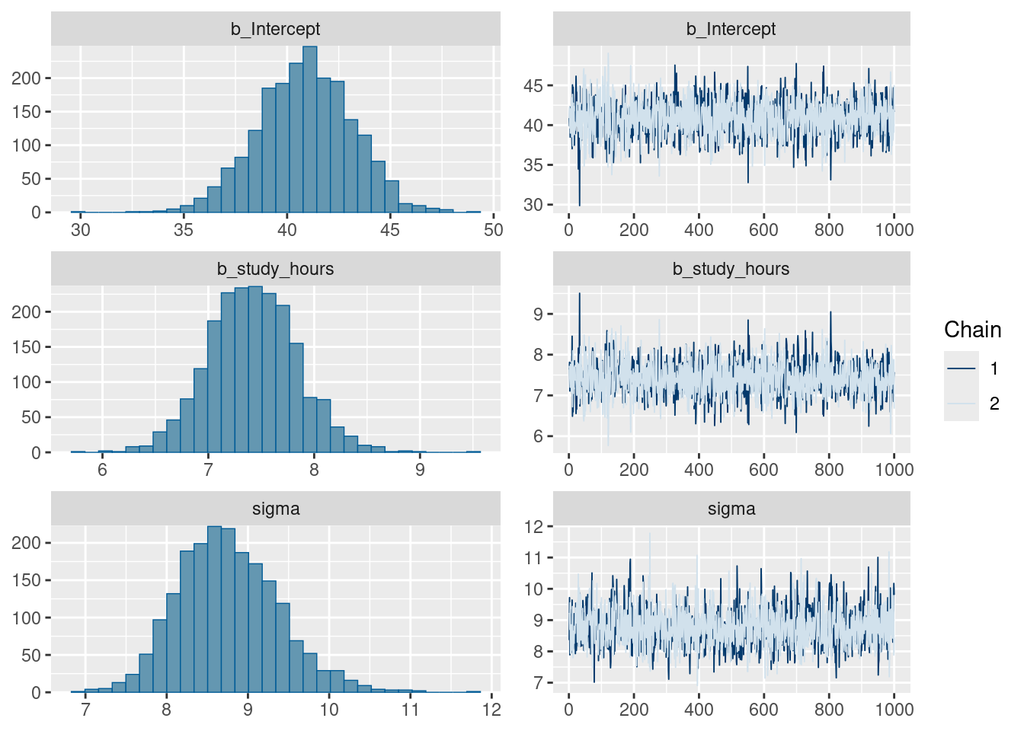

```r
# Plot posterior distributions
plot(model1)
```

Extract and visualize specific parameters:

```r
# Extract posterior samples
posterior_samples <- as_draws_df(model1)
head(posterior_samples)
```

```
## # A draws_df: 6 iterations, 1 chains, and 6 variables
##   b_Intercept b_study_hours sigma Intercept lprior lp__
## 1          41           7.6   8.4        80   -7.1 -363
## 2          40           7.8   9.7        80   -7.1 -364
## 3          42           7.1   7.9        78   -7.0 -363
## 4          38           7.8   9.3        78   -7.1 -363
## 5          41           7.3   9.1        78   -7.1 -362
## 6          39           7.7   8.2        78   -7.1 -362
## # ... hidden reserved variables {'.chain', '.iteration', '.draw'}
```

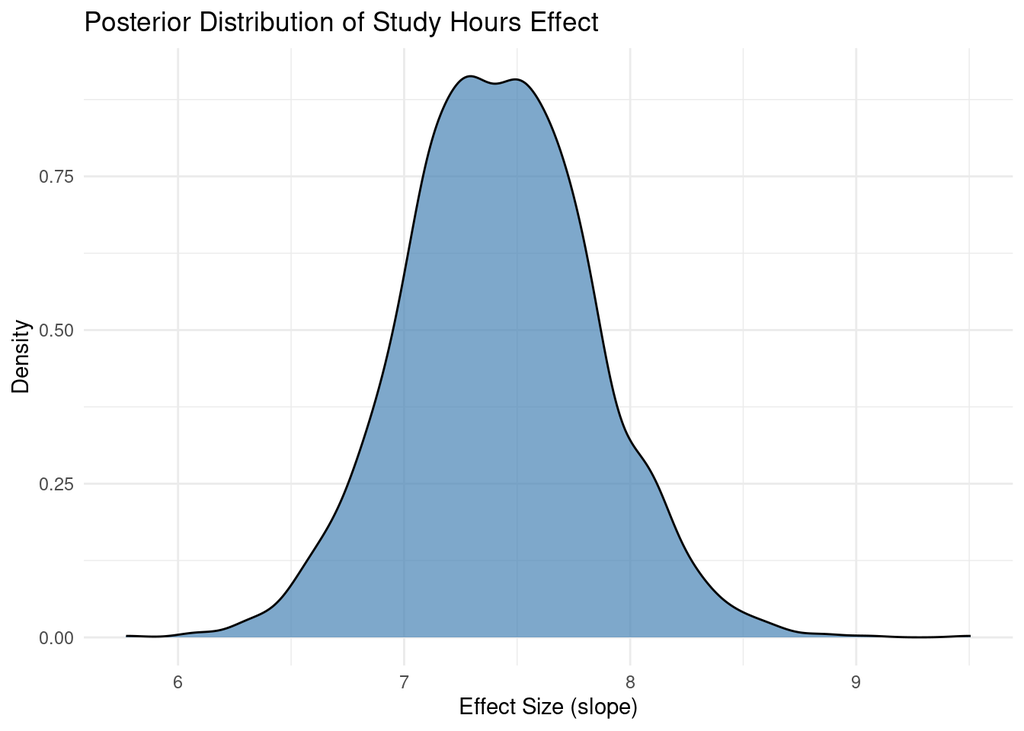

```r
# Plot intercept and slope
posterior_samples %>%
  ggplot(aes(x = b_study_hours)) +
  geom_density(fill = "steelblue", alpha = 0.7) +
  theme_minimal() +
  labs(
    title = "Posterior Distribution of Study Hours Effect",
    x = "Effect Size (slope)",
    y = "Density"
  )
```

# Part 4: Custom Priors

Specify custom priors for the model:

```r
# Check default priors
prior_summary(model1)
```

```
##                     prior     class        coef group resp dpar nlpar lb ub tag
##                    (flat)         b
##                    (flat)         b study_hours
##  student_t(3, 79.9, 16.3) Intercept
##     student_t(3, 0, 16.3)     sigma                                    0
##        source
##       default
##  (vectorized)
##       default
##       default
```

```r
# Define custom priors
custom_priors <- c(
  prior(normal(50, 10), class = "Intercept"),
  prior(normal(8, 2), class = "b"),
  prior(exponential(1), class = "sigma")
)

# Model with custom priors
model2 <- brm(
  formula = score ~ study_hours,
  data = data_study,
  family = gaussian(),
  prior = custom_priors,
  chains = 2,
  iter = 2000,
  warmup = 1000,
  cores = 2,
  refresh = 0
)
```

```
## Running MCMC with 2 parallel chains...
##
## Chain 1 finished in 0.0 seconds.
## Chain 2 finished in 0.0 seconds.
##
## Both chains finished successfully.
## Mean chain execution time: 0.0 seconds.
## Total execution time: 0.4 seconds.
```

```r
cat("Model 2 with custom priors complete!\n")
```

```
## Model 2 with custom priors complete!
```

# Part 5: Model Comparison

Compare models using Leave-One-Out (LOO) cross-validation:

```r
# Add LOO criterion
model1_loo <- add_criterion(model1, "loo")
model2_loo <- add_criterion(model2, "loo")

# Compare
loo_compare(model1_loo, model2_loo)
```

```
##            elpd_diff se_diff
## model1_loo  0.0       0.0
## model2_loo -0.2       0.8
```

# Part 6: Predictions

Make predictions with the model:

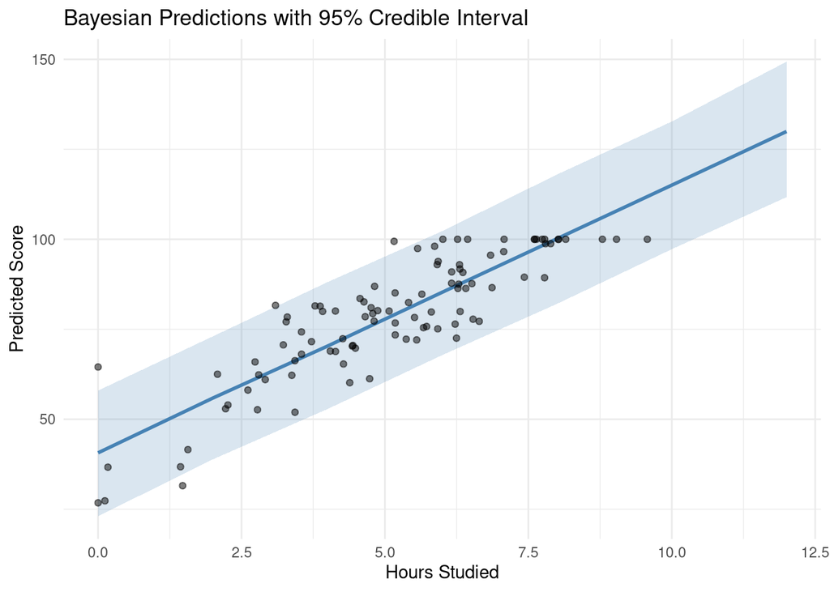

```r
# Create new data for prediction
new_data <- data.frame(
  study_hours = seq(0, 12, by = 2)
)

# Get predicted values with uncertainty
predictions <- posterior_predict(model1, newdata = new_data, re_formula = NA)

# Calculate summaries
pred_summary <- data.frame(
  study_hours = new_data$study_hours,
  mean = colMeans(predictions),
  lower = apply(predictions, 2, quantile, probs = 0.025),
  upper = apply(predictions, 2, quantile, probs = 0.975)
)

# Plot predictions
ggplot(pred_summary, aes(x = study_hours, y = mean)) +
  geom_line(color = "steelblue", size = 1) +
  geom_ribbon(aes(ymin = lower, ymax = upper), alpha = 0.2, fill = "steelblue") +
  geom_point(data = data_study, aes(x = study_hours, y = score), alpha = 0.5) +
  theme_minimal() +
  labs(
    title = "Bayesian Predictions with 95% Credible Interval",
    x = "Hours Studied",
    y = "Predicted Score"
  )
```

# Summary

Congratulations! You’ve learned:

1. ✅ Loading data and fitting a Bayesian regression model
2. ✅ Understanding posterior distributions
3. ✅ Visualizing results
4. ✅ Specifying custom priors
5. ✅ Comparing models with LOO
6. ✅ Making predictions with uncertainty

## Next Steps

- Explore hierarchical models for grouped data
- Fit models with different families (Poisson, binomial, etc.)
- Use regularizing priors for complex models
- Check model diagnostics (Rhat, ESS)

## Resources

- **BRMS Documentation**: https://paul-buerkner.github.io/brms/
- **Stan Manual**: https://mc-stan.org/docs/
- **Bayesian Visualization**: https://mc-stan.org/bayesplot/articles/

**Happy Bayesian modeling!** 🎓